# Vaccination Mini Project

Ralph Goguanco

3/11/2022

The goal of this hands-on mini-project is to examine and compare the Covid-19 vaccination rates around San Diego.

```r
# Import vaccination data
vax <- read.csv("covid19vaccinesbyzipcode_test.csv")
head(vax)
```

|  | as_of_date | zip_code_tabulation_area | local_health_jurisdiction | county | vaccine_equity_metric_quartile | vem_source | age12_plus_population | age5_plus_population | persons_fully_vaccinated | persons_partially_vaccinated | percent_of_population_fully_vaccinated | percent_of_population_partially_vaccinated | percent_of_population_with_1_plus_dose | booster_recip_count | redacted |
| --- | --- | --- | --- | --- | --- | --- | --- | --- | --- | --- | --- | --- | --- | --- | --- |
| 1 | 2021-01-05 | 95959 | Nevada | Nevada | 3 | Healthy Places Index Score | 16558.5 | 17604 | NA | NA | NA | NA | NA | NA | Information redacted in accordance with CA state privacy requirements |
| 2 | 2021-01-05 | 95694 | Yolo | Yolo | 3 | Healthy Places Index Score | 8658.1 | 9646 | NA | NA | NA | NA | NA | NA | Information redacted in accordance with CA state privacy requirements |
| 3 | 2021-01-05 | 95714 | Placer | Placer | 2 | CDPH-Derived ZCTA Score | 477.7 | 511 | NA | NA | NA | NA | NA | NA | Information redacted in accordance with CA state privacy requirements |
| 4 | 2021-01-05 | 95843 | Sacramento | Sacramento | 3 | Healthy Places Index Score | 38637.1 | 44055 | NA | NA | NA | NA | NA | NA | Information redacted in accordance with CA state privacy requirements |
| 5 | 2021-01-05 | 95935 | Yuba | Yuba | 3 | CDPH-Derived ZCTA Score | 206.0 | 206 | NA | NA | NA | NA | NA | NA | Information redacted in accordance with CA state privacy requirements |
| 6 | 2021-01-05 | 95970 | Colusa | Colusa | 2 | CDPH-Derived ZCTA Score | 564.9 | 611 | NA | NA | NA | NA | NA | NA | Information redacted in accordance with CA state privacy requirements |

> Q1. What column details the total number of people fully vaccinated?

persons_fully_vaccinated

> Q2. What column details the Zip code tabulation area?

zip_code_tabulation_area

> Q3. What is the earliest date in this dataset?

```r
head(vax$as_of_date)
```

```
## [1] "2021-01-05" "2021-01-05" "2021-01-05" "2021-01-05" "2021-01-05"
## [6] "2021-01-05"
```

```r
#2021-01-05
```

> Q4. What is the latest date in this dataset?

```r
tail(vax$as_of_date)
```

```
## [1] "2022-03-08" "2022-03-08" "2022-03-08" "2022-03-08" "2022-03-08"
## [6] "2022-03-08"
```

```r
#2022-03-08
```

As we have done previously, let’s call the skim() function from the skimr package to get a quick overview of this dataset:

```r
skimr::skim(vax)
```

Data summary

| Name | vax |
| --- | --- |
| Number of rows | 109368 |
| Number of columns | 15 |
| _______________________ |  |
| Column type frequency: |  |
| character | 5 |
| numeric | 10 |
| ________________________ |  |
| Group variables | None |

**Variable type: character**

| skim_variable | n_missing | complete_rate | min | max | empty | n_unique | whitespace |
| --- | --- | --- | --- | --- | --- | --- | --- |
| as_of_date | 0 | 1 | 10 | 10 | 0 | 62 | 0 |
| local_health_jurisdiction | 0 | 1 | 0 | 15 | 310 | 62 | 0 |
| county | 0 | 1 | 0 | 15 | 310 | 59 | 0 |
| vem_source | 0 | 1 | 15 | 26 | 0 | 3 | 0 |
| redacted | 0 | 1 | 2 | 69 | 0 | 2 | 0 |

**Variable type: numeric**

| skim_variable | n_missing | complete_rate | mean | sd | p0 | p25 | p50 | p75 | p100 | hist |
| --- | --- | --- | --- | --- | --- | --- | --- | --- | --- | --- |
| zip_code_tabulation_area | 0 | 1.00 | 93665.11 | 1817.39 | 90001 | 92257.75 | 93658.50 | 95380.50 | 97635.0 | ▃▅▅▇▁ |
| vaccine_equity_metric_quartile | 5394 | 0.95 | 2.44 | 1.11 | 1 | 1.00 | 2.00 | 3.00 | 4.0 | ▇▇▁▇▇ |
| age12_plus_population | 0 | 1.00 | 18895.04 | 18993.91 | 0 | 1346.95 | 13685.10 | 31756.12 | 88556.7 | ▇▃▂▁▁ |
| age5_plus_population | 0 | 1.00 | 20875.24 | 21106.01 | 0 | 1460.50 | 15364.00 | 34877.00 | 101902.0 | ▇▃▂▁▁ |
| persons_fully_vaccinated | 18494 | 0.83 | 12246.65 | 13155.33 | 11 | 1074.00 | 7453.00 | 20138.00 | 79763.0 | ▇▃▁▁▁ |
| persons_partially_vaccinated | 18494 | 0.83 | 848.69 | 1401.05 | 11 | 77.00 | 377.00 | 1091.00 | 36844.0 | ▇▁▁▁▁ |
| percent_of_population_fully_vaccinated | 18494 | 0.83 | 0.51 | 0.26 | 0 | 0.34 | 0.55 | 0.71 | 1.0 | ▅▅▇▇▃ |
| percent_of_population_partially_vaccinated | 18494 | 0.83 | 0.05 | 0.10 | 0 | 0.02 | 0.03 | 0.05 | 1.0 | ▇▁▁▁▁ |
| percent_of_population_with_1_plus_dose | 18494 | 0.83 | 0.55 | 0.28 | 0 | 0.36 | 0.59 | 0.76 | 1.0 | ▅▃▆▇▅ |
| booster_recip_count | 64441 | 0.41 | 4265.63 | 6073.54 | 11 | 183.00 | 1207.00 | 6484.00 | 51001.0 | ▇▁▁▁▁ |

```r
N <- sum(is.na(vax$persons_fully_vaccinated))
total <- sum(vax$percent_of_population_fully_vaccinated, na.rm = TRUE)
```

> What percent of persons_fully_vaccinated values are missing (to 2 significant figures)?

```r
N/total
```

```
## [1] 0.3959551
```

#Working with dates

```r
library(lubridate)
today()
```

```
## [1] "2022-03-11"
```

```r
#Specify that we are using the year-month-day format
vax$as_of_date <- ymd(vax$as_of_date)
```

```r
today() - vax$as_of_date[1]
```

```
## Time difference of 430 days
```

> Q9. How many days have passed since the last update of the dataset? 3 days

```r
today() - vax$as_of_date[109358]
```

```
## Time difference of 3 days
```

> Q10. How many unique dates are in the dataset (i.e. how many different dates are detailed)? 62

```r
date_uniq <- unique(vax$as_of_date)
length(date_uniq)
```

```
## [1] 62
```

#Working with ZIP codes

```r
library(zipcodeR)
# Pull data for all ZIP codes in the dataset
zipdata <- reverse_zipcode( vax$zip_code_tabulation_area )
```

```r
# Subset to San Diego county only areas
sd <- vax[ 4 , ]
```

```r
library(dplyr)
sd <- filter(vax, county == "San Diego")

nrow(sd)
```

```
## [1] 6634
```

> Q11. How many distinct zip codes are listed for San Diego County?

```r
length(unique(sd))
```

```
## [1] 15
```

> Q12. What San Diego County Zip code area has the largest 12 + Population in this dataset?

```r
which.max(sd[, 7])
```

```
## [1] 103
```

```r
# Zip Code in #103 is 92154
```

```r
sd1 <- filter(sd, as_of_date == "2022-02-22")
```

> Q13. What is the overall average “Percent of Population Fully Vaccinated” value for all San Diego “County” as of “2022-02-22”?

```r
mean(sd1$percent_of_population_fully_vaccinated, na.rm = TRUE)
```

```
## [1] 0.7145899
```

71.46%

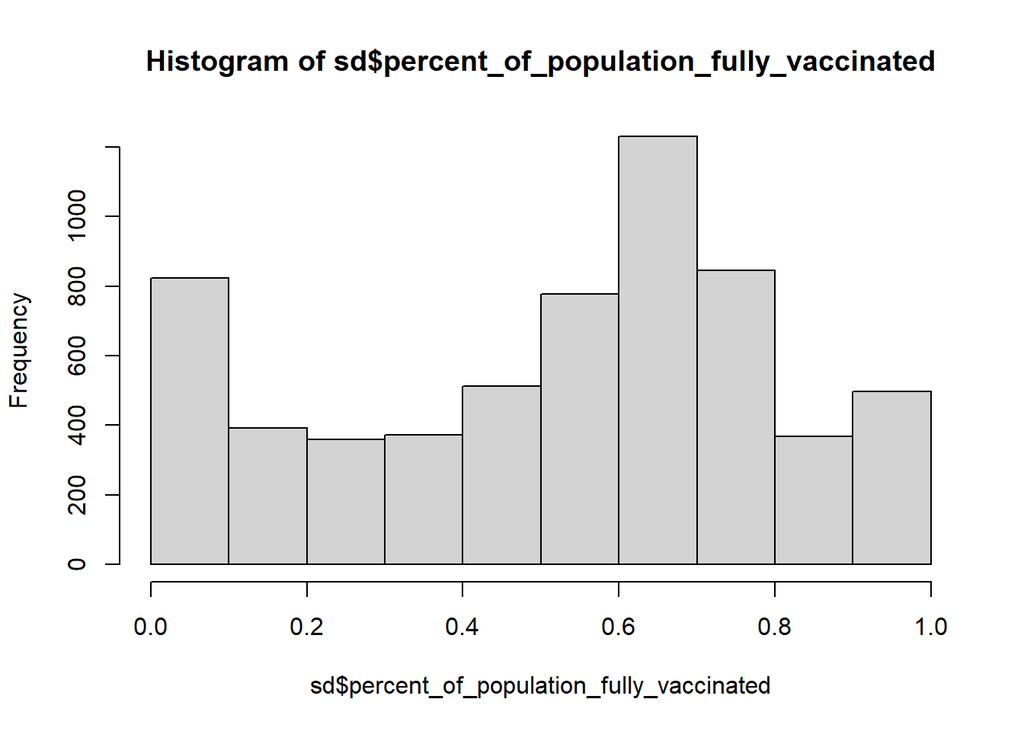

```r
hist(sd$percent_of_population_fully_vaccinated)
```

Focus on UCSD/La Jolla

```r
ucsd <- filter(sd, zip_code_tabulation_area=="92037")
ucsd[1,]$age5_plus_population
```

```
## [1] 36144
```

> Q15. Using ggplot make a graph of the vaccination rate time course for the 92037 ZIP code area:

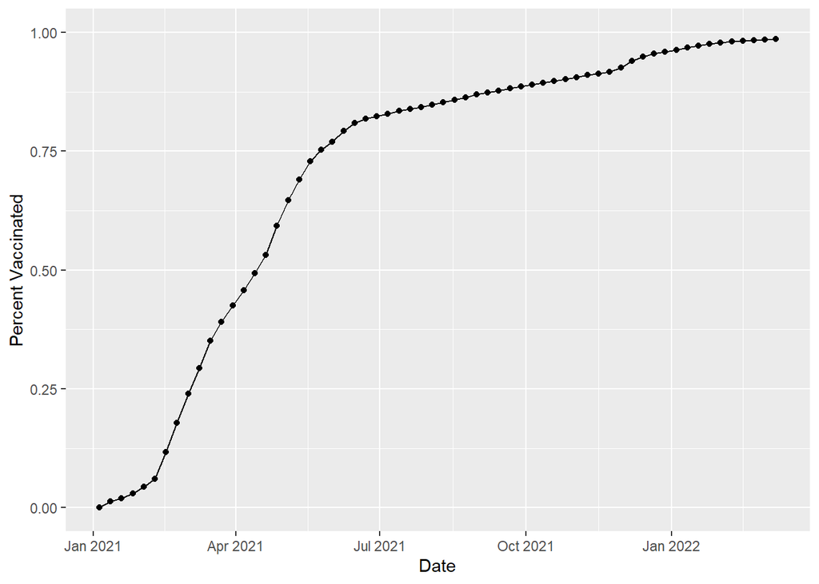

```r
library(ggplot2)
ggplot(ucsd) +
  aes(x=ucsd$as_of_date,
      y = ucsd$percent_of_population_fully_vaccinated) +
  geom_point() +
  geom_line(group=1) +
  ylim(c(0,1)) +
  labs(x="Date", y="Percent Vaccinated")
```

Comparing to similar sized areas

```r
# Subset to all CA areas with a population as large as 92037
vax.36 <- filter(vax, age5_plus_population > 36144 &
                as_of_date == "2022-02-22")

head(vax.36)
```

|  | as_of_date | zip_code_tabulation_area | local_health_jurisdiction | county | vaccine_equity_metric_quartile | vem_source | age12_plus_population | age5_plus_population | persons_fully_vaccinated | persons_partially_vaccinated | percent_of_population_fully_vaccinated | percent_of_population_partially_vaccinated | percent_of_population_with_1_plus_dose | booster_recip_count | redacted |
| --- | --- | --- | --- | --- | --- | --- | --- | --- | --- | --- | --- | --- | --- | --- | --- |
| 1 | 2022-02-22 | 94110 | San Francisco | San Francisco | 4 | Healthy Places Index Score | 64350.7 | 68320 | 61497 | 4653 | 0.900132 | 0.068106 | 0.968238 | 40483 | No |
| 2 | 2022-02-22 | 93552 | Los Angeles | Los Angeles | 1 | Healthy Places Index Score | 32533.5 | 37174 | 26810 | 2301 | 0.721203 | 0.061898 | 0.783101 | 10572 | No |
| 3 | 2022-02-22 | 93611 | Fresno | Fresno | 3 | Healthy Places Index Score | 40280.7 | 45640 | 30264 | 2613 | 0.663103 | 0.057252 | 0.720355 | 15406 | No |
| 4 | 2022-02-22 | 92336 | San Bernardino | San Bernardino | 2 | Healthy Places Index Score | 81443.7 | 92279 | 65257 | 5206 | 0.707171 | 0.056416 | 0.763587 | 29495 | No |
| 5 | 2022-02-22 | 95116 | Santa Clara | Santa Clara | 2 | Healthy Places Index Score | 45781.3 | 51595 | 40346 | 3109 | 0.781975 | 0.060258 | 0.842233 | 20380 | No |
| 6 | 2022-02-22 | 92571 | Riverside | Riverside | 1 | Healthy Places Index Score | 45460.0 | 52782 | 31888 | 3663 | 0.604145 | 0.069399 | 0.673544 | 11079 | No |

> Q16. Calculate the mean “Percent of Population Fully Vaccinated” for ZIP code areas with a population as large as 92037 (La Jolla) as_of_date “2022-02-22”. Add this as a straight horizontal line to your plot from above with the geom_hline() function?

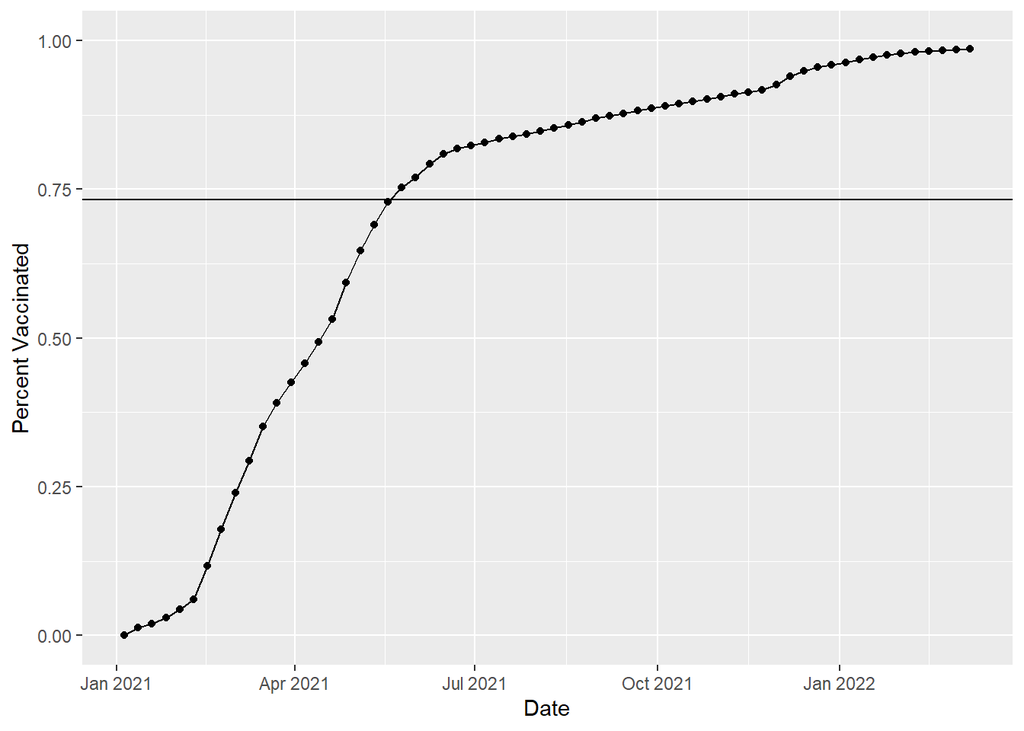

```r
ggplot(ucsd) +
aes(x=ucsd$as_of_date,
      y = ucsd$percent_of_population_fully_vaccinated) +
  geom_point() +
  geom_line(group=1) +
  ylim(c(0,1)) +
  labs(x="Date", y="Percent Vaccinated") +
  geom_hline(yintercept = 0.732736)
```

```r
#fivenum(vax.36)
```

> Q18. Using ggplot generate a histogram of this data.

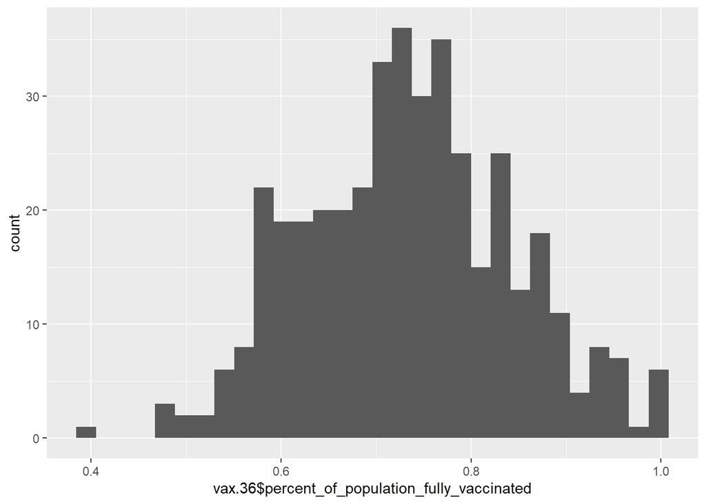

```r
ggplot(vax.36, aes(x=vax.36$percent_of_population_fully_vaccinated)) +
geom_histogram()
```

> Q19. Is the 92109 and 92040 ZIP code areas above or below the average value you calculated for all these above?

```r
vax %>% filter(as_of_date == "2022-02-22") %>%
  filter(zip_code_tabulation_area=="92040") %>%
  select(percent_of_population_fully_vaccinated)
```

| percent_of_population_fully_vaccinated |
| --- |
| 0.559102 |

Below the average value

```r
#vax.36.all <- filter(vax, age5_plus_population > 36144)


#ggplot(vax.36.all) +
# aes(x = vax.36$as_of_date,
#      percent_of_population_fully_vaccinated,
#      group=zip_code_tabulation_area) +
#  geom_line(alpha=0.2, color=vax) +
#  ylim(vax.36) +
# labs(x="Date" , y="Percent",
#       title="Vaccination rate accross California",
#       subtitle="Only areas with a population above 36k are shown") +
#  geom_hline(yintercept = 0.7327, linetype=dash)
```

> Q21. How do you feel about traveling for Spring Break and meeting for in-person class afterwards?

I feel better knowing that the percent vaccinated will only go up